# Bilgi Yönetim Sistemleri - Bitirme Projesi Rapor : Semih Sarı 200401071, Merve Yılmaz 210401009, Berat Öcal 200401017, Ümit Atakan Günel 210401004

## Q1: İş probleminin tanımı

Şirketimiz, hizmet verenler ile hizmet almak isteyenleri buluşturmaktadır. Kullanıcılar, bilgisayar veya akıllı telefonları üzerinden birkaç dokunuşla temizlik, tadilat, nakliyat gibi çeşitli hizmetlere kolayca ulaşabilmektedir. Bu raporda, Troia platformunda hizmet alan kullanıcıların almış oldukları servis ve kategorileri içeren veri seti kullanılarak, Association Rule Learning yöntemi ile bir ürün tavsiye sistemi oluşturulması hedeflenmektedir.Bu sistem, kullanıcıların ilgilerine göre hizmet önerileri sunarak müşteri memnuniyetini ve hizmet kalitesini artırmayı amaçlamaktadır.

SuiteCRM’in müşteri yönetimi, satış yönetimi, pazarlama otomasyonu ve raporlama özelliklerinden yararlanılarak bu hedefe ulaşılacaktır. SuiteCRM’in açık kaynaklı ve özelleştirilebilir yapısı, düşük maliyetli ve esnek çözümler sunarak iş süreçlerinin optimize edilmesine katkı sağlayacaktır. Bu nedenle SuiteCRM, bu proje için ideal bir BYS platformu olarak seçilmiştir.

## Q2: İş problemini çözmede kullanılacak data seti

### Veri Seti

*Veri seti müşterilerin aldıkları servislerden ve bu servislerin kategorilerinden oluşmaktadır.* *Alınan her hizmetin tarih ve saat bilgisini içermektedir.*

- **UserId**: Müşteri numarası
- **ServiceId**: Her kategoriye ait anonimleştirilmiş servislerdir. (Örnek : *Temizlik* kategorisi altında *koltuk yıkama* servisi)
  - *Bir ServiceId farklı kategoriler altında bulanabilir ve farklı kategoriler altında farklı servisleri ifade eder.*
  - (Örnek: CategoryId’si *7* ServiceId’si *4* olan hizmet *petek temizliği* iken CategoryId’si *2* ServiceId’si *4* olan hizmet *mobilya montaj*)
- **CategoryId**: Anonimleştirilmiş kategorilerdir. (Örnek : *Temizlik, nakliyat, tadilat* kategorisi)
- **CreateDate**: Hizmetin satın alındığı tarih
- **Ad**: Müşteri adı
- **Soyad**: Müşteri soyadı
- **email**: Müşteri e-posta adresi

| UserId | ServiceId | CategoryId | CreateDate | Ad | Soyad | email |
| --- | --- | --- | --- | --- | --- | --- |
| 25446 | 4 | 5 | 2017-08-06 16:11:00 | Zachary | Hess | rosborne@example.org |
| 22948 | 48 | 5 | 2017-08-06 16:12:00 | Amber | Floyd | masseykimberly@example.org |
| 10618 | 0 | 8 | 2017-08-06 16:13:00 | Kayla | Hernandez | mitchelltricia@example.com |
| 7256 | 9 | 4 | 2017-08-06 16:14:00 | Melissa | Lee | craig75@example.com |
| 25446 | 48 | 5 | 2017-08-06 16:16:00 | John | Williams | tashafowler@example.org |
| 14354 | 15 | 1 | 2017-08-06 16:27:00 | Stephanie | Conrad | knolan@example.com |

### Veri Seti Kaynağı

Bu veri seti, Kaggle platformundan bulunmuştur. [Armut Data](https://www.kaggle.com/datasets/sumeyraaksekiboz/armut-data/data) adlı veri setidir.

- **Veriyi Toplayan/Yaratanlar**: Veri setini oluşturanlar, Armut platformu tarafından müşterilerin hizmet satın alma işlemleri sırasında otomatik olarak toplanmış verileri derlemiştir.
- **Veri Toplama Yöntemi**: Armut platformu, kullanıcıların platform üzerindeki hizmet taleplerini ve satın alımlarını kaydederek bu veriyi oluşturmuştur.

### Veri Üzerinde Yapılan Değişiklikler

Veri seti üzerinde herhangi bir değişiklik yapılmamıştır. Ancak sentetik veri eklemek için ad, soyad ve e-posta bilgileri gibi ek alanlar oluşturulmuştur.

### Sentetik Veri Üretimi

Sentetik veri eklemek için ad, soyad ve e-posta bilgileri gibi ek alanlar oluşturulmuştur. Bu bilgiler, gerçek kullanıcı verilerinden türetilmemiş ve rastgele oluşturulmuştur. Sentetik veri eklemek için kullanılan süreç, sentetik veri üretimi için yaygın olarak kullanılan Python kütüphaneleri kullanılarak gerçekleştirilmiştir.

**Sonuç** Bu veri seti, müşterilerin hizmet satın alma alışkanlıklarını analiz etmek ve hizmet kategorileri arasındaki ilişkileri incelemek için kullanılacaktır. Kaggle platformundan elde edilen bu veri seti, gerçek dünya kullanıcı davranışlarını temsil etmektedir ve çeşitli analizler için potansiyel sunmaktadır. Sentetik veri eklenerek, veri setinin zenginleştirilmesi ve daha geniş kapsamlı analizler yapılabilmesi sağlanmıştır.

## Q3: Veri Seti Keşifsel Analizi

### Önemli Sütunlar ve Veri Tipleri

*Bu tabloda veri setindeki önemli sütunlar ve bunların veri tipleri yer almaktadır.*

Önemli Sütunlar ve Veri Tipleri

| Sutun | Veri_Tipi |
| --- | --- |
| UserId | Sayısal |
| ServiceId | Sayısal |
| CategoryId | Sayısal |
| CreateDate | Tarih/Zaman |
| Ad | Metin |
| Soyad | Metin |
| email | Metin |

### Özellik Çıkarımı

#### Hizmet Sütununun Oluşturulması

Veri setinde ServiceId ve CategoryId sütunları birleştirilerek yeni bir Hizmet sütunu oluşturulmuştur. Bu işlem, her hizmetin kategorisiyle birlikte benzersiz bir tanımının yapılmasını sağlamaktadır. Bu sayede, hizmet ve kategori ilişkisi daha net bir şekilde analiz edilebilmektedir.

#### Sepet Tanımının Oluşturulması

Veri seti hizmetlerin alındığı tarih ve saat bilgilerini içermektedir, ancak herhangi bir sepet tanımı (örneğin fatura vb.) bulunmamaktadır. Association Rule Learning uygulayabilmek için bir sepet tanımı oluşturulması gerekmektedir. Bu çalışmada, sepet tanımı her bir müşterinin aylık aldığı hizmetler olarak belirlenmiştir.

Örneğin, 7256 id’li müşteri 2017’nin 8. ayında aldığı hizmetler bir sepeti, 2017’nin 10. ayında aldığı hizmetler ise başka bir sepeti ifade etmektedir. Sepetleri benzersiz bir ID ile tanımlamak için öncelikle sadece yıl ve ay içeren yeni bir NEW_DATE değişkeni oluşturulmuş ve UserId ile bu yeni tarih değişkeni birleştirilerek SepetID adlı yeni bir değişken oluşturulmuştur.

| UserId | Hizmet | NEW_DATE | SepetID |
| --- | --- | --- | --- |
| 7256 | 9_4 | 2017-08 | 7256_2017-08 |
| 7256 | 46_4 | 2017-08 | 7256_2017-08 |
| 7256 | 46_4 | 2017-08 | 7256_2017-08 |

**SepetID Sütununun Oluşturulması**

Her bir müşterinin aylık aldığı hizmetlerin bir sepet olarak tanımlanabilmesi için `SepetID` sütunu oluşturulmuştur. Bu işlem, kullanıcı kimliği (`UserId`) ve hizmetin alındığı tarih (`CreateDate`) kullanılarak yapılmıştır. `CreateDate` sütunundan sadece yıl ve ay bilgileri alınarak `NEW_DATE` sütunu oluşturulmuş ve ardından `UserId` ile birleştirilerek `SepetID` sütunu elde edilmiştir.

*Aşağıdaki tabloda veri setinin son hali görünmektedir.*

| UserId | ServiceId | CategoryId | CreateDate | Ad | Soyad | email | Hizmet | NEW_DATE | SepetID |
| --- | --- | --- | --- | --- | --- | --- | --- | --- | --- |
| 25446 | 4 | 5 | 2017-08-06 16:11:00 | Zachary | Hess | rosborne@example.org | 4_5 | 2017-08 | 25446_2017-08 |
| 22948 | 48 | 5 | 2017-08-06 16:12:00 | Amber | Floyd | masseykimberly@example.org | 48_5 | 2017-08 | 22948_2017-08 |
| 10618 | 0 | 8 | 2017-08-06 16:13:00 | Kayla | Hernandez | mitchelltricia@example.com | 0_8 | 2017-08 | 10618_2017-08 |
| 7256 | 9 | 4 | 2017-08-06 16:14:00 | Melissa | Lee | craig75@example.com | 9_4 | 2017-08 | 7256_2017-08 |
| 25446 | 48 | 5 | 2017-08-06 16:16:00 | John | Williams | tashafowler@example.org | 48_5 | 2017-08 | 25446_2017-08 |
| 14354 | 15 | 1 | 2017-08-06 16:27:00 | Stephanie | Conrad | knolan@example.com | 15_1 | 2017-08 | 14354_2017-08 |

### Eksik Veri Analizi

*Veri setindeki eksik verilerin analizi yapılmıştır. Bu analiz, hangi sütunlarda ve ne oranda eksik veri bulunduğunu göstermektedir.*

|  | Sutun | Eksik_Veri_Yuzdesi |
| --- | --- | --- |
| UserId | UserId | 0 |
| ServiceId | ServiceId | 0 |
| CategoryId | CategoryId | 0 |
| CreateDate | CreateDate | 0 |
| Ad | Ad | 0 |
| Soyad | Soyad | 0 |
| email | email | 0 |
| Hizmet | Hizmet | 0 |
| NEW_DATE | NEW_DATE | 0 |
| SepetID | SepetID | 0 |

### Kategorik Değişken Dağılımı

Kategori dağılımı, her bir kategoride bulunan hizmet sayısını göstermektedir. Aşağıdaki grafik, veri setinde en çok alınan hizmet kategorilerini görselleştirmektedir.

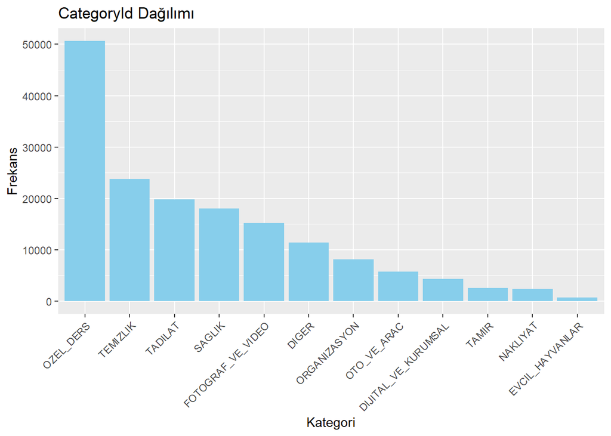

*Grafikten görüleceği üzere, veri setinde en çok alınan hizmet kategorisi birinci sırada 4 ID’li “OZEL_DERS” kategorisi, ikinci sırada ise 0 ID’li “Temizlik” kategorisi yer almaktadır*

### Benzersiz Değer Kontrolü

Veri setindeki sütunlarda kaç farklı benzersiz değer bulunduğu incelenmiştir. Bu analiz, veri setindeki çeşitliliği ve potansiyel anormallikleri tespit etmeye yardımcı olmaktadır.

Benzersiz Değerler

|  | Sutun | Benzersiz_Degerler |
| --- | --- | --- |
| UserId | UserId | 24826 |
| ServiceId | ServiceId | 50 |
| CategoryId | CategoryId | 12 |
| CreateDate | CreateDate | 117510 |
| Ad | Ad | 690 |
| Soyad | Soyad | 1000 |
| email | email | 130494 |
| Hizmet | Hizmet | 50 |
| NEW_DATE | NEW_DATE | 13 |
| SepetID | SepetID | 71220 |
| CategoryString | CategoryString | 12 |

### Sayısal Değişkenler İçin Temel İstatistikler

Sayısal ve tarih bilgisi içeren değişkenler için temel istatistikler hesaplanmıştır. Bu istatistikler, veri setindeki sayısal değerlerin genel dağılımını ve özetini sunmaktadır.

Sayısal Değişkenler İçin Temel İstatistikler

|  | UserId | ServiceId | CategoryId | CreateDate | CategoryString |
| --- | --- | --- | --- | --- | --- |
|  | Min. : 0 | Min. : 0.00 | Min. : 0.000 | Min. :2017-08-06 16:11:00.00 | Length:162523 |
|  | 1st Qu.: 6953 | 1st Qu.:13.00 | 1st Qu.: 1.000 | 1st Qu.:2017-11-09 09:24:30.00 | Class :character |
|  | Median :13139 | Median :18.00 | Median : 4.000 | Median :2018-02-02 01:00:00.00 | Mode :character |
|  | Mean :13090 | Mean :21.64 | Mean : 4.326 | Mean :2018-01-31 12:06:26.28 | NA |
|  | 3rd Qu.:19396 | 3rd Qu.:32.00 | 3rd Qu.: 6.000 | 3rd Qu.:2018-04-24 19:55:00.00 | NA |
|  | Max. :25744 | Max. :49.00 | Max. :11.000 | Max. :2018-08-06 16:04:00.00 | NA |

## Q4: Veri Setinin BYS Platformuna İhtali

1. **SuiteCRM’in AWS Üzerine Kurulumu:** SuiteCRM, müşteri ilişkileri yönetimi için açık kaynaklı bir platformdur. AWS (Amazon Web Services) üzerinde SuiteCRM kurulumu gerçekleştirerek, müşteri verilerini etkili bir şekilde yönetmek ve iş süreçlerini optimize etmek için bir altyapı oluşturulmuştur. AWS’nin sağladığı esneklik ve güvenilirlik, SuiteCRM’in bulut tabanlı bir çözüm olarak hızlı ve verimli bir şekilde kurulmasını sağlamıştır.
2. **Veri Seti İçin Modül Oluşturma:** SuiteCRM, modüler bir yapıya sahiptir ve kullanıcılar özelleştirilmiş modüller oluşturarak platformu ihtiyaçlarına göre şekillendirebilirler. Bu bağlamda, proje için gereken veri setine uygun bir modül oluşturulmuştur. Bu modül, müşterilerin hizmet alımıyla ilgili verileri depolamak ve yönetmek için tasarlanmıştır. Modül, müşteri verilerini düzenli bir şekilde kaydetmek ve erişmek için gerekli araçları sağlar.
3. **Veri Seti Dosyasının CSV Formatında Yüklenmesi:** Oluşturulan modül üzerine, proje için gereken veri seti dosyası sistem arayüzü kullanılarak CSV formatında yüklenmiştir. CSV formatı, veri setlerini kolayca okunabilir ve işlenebilir hale getirir. Veri seti, SuiteCRM’in sağladığı veri yönetim araçları kullanılarak sisteme yüklenmiştir. Bu adım, veri setinin CRM platformuna entegrasyonunu sağlar ve veri setinin SuiteCRM içinde kullanılabilir hale gelmesini sağlar.

   Veri yükleme işlemi sırasında API kullanılmamıştır, ancak SuiteCRM’in sağladığı API’ler sayesinde bu işlem gerçekleştirilebilir. API’ler, farklı sistemler arasında veri alışverişi yapılmasını sağlar ve otomatik veri senkronizasyonunu mümkün kılar. Bu nedenle, projenin ilerleyen aşamalarında veri çekme işlemlerinde SuiteCRM REST API’den yararlanılacaktır.

## Q5 : Yapılması planlanan veri analizi

### Hizmet Tavsiye Sistemi Oluşturma:

#### Görev 1: Veriyi Hazırlama

1. **Veri Okuma ve Temizleme**
2. **Hizmetleri Temsil Eden Yeni Değişkenin Oluşturulması:**
   - ServiceId ve CategoryId birleştirilerek hizmetleri temsil eden yeni bir değişken oluşturulacak. Bu, her hizmetin kategoriye ve hizmete göre tekil olarak tanımlanmasını sağlayacak.
3. **Sepet Tanımının Oluşturulması:**
   - Müşterilerin aylık aldıkları hizmetler sepet olarak tanımlanacak ve her bir sepete benzersiz bir ID atanacak. Bu, her müşterinin hizmet alımlarının zaman içinde nasıl değiştiğini izlememize olanak tanıyacak.

#### Görev 2: Birliktelik Kuralları Üretme

1. **Sepet-Hizmet Pivot Tablosunun Oluşturulması:**
   - Müşterilerin aldıkları hizmetleri içeren bir sepet-hizmet pivot tablosu oluşturulacak. Bu tablo, her bir müşteri sepetinin hizmetlerle ilişkisini gösterecek.
2. **Apriori Algoritması Kullanarak Birliktelik Kurallarının Üretilmesi:**
   - Apriori algoritması, müşterilerin birlikte aldığı hizmetler arasındaki ilişkileri belirlemek için kullanılacak. Belirli bir destek değeri üzerinde olan sık görülen hizmet kombinasyonlarını tespit edecek.
3. **Hizmet Önerisinde Bulunma:**
   - Belirli bir hizmeti alan bir kullanıcıya hizmet önerisinde bulunulacak. Bu öneri, Apriori algoritması ile tespit edilen birliktelik kurallarına dayanarak yapılacak. Önerilen hizmetler, müşterinin geçmiş alımları ve benzer müşterilerin tercihleri dikkate alınarak belirlenecek.

#### Zaman Serisi Analizi Yapma

1. **Veri Hazırlığı**
2. **Zaman Serisi Analizi Yöntemlerinin Uygulanması:**
   - Zaman serisi analizi için uygun yöntemler seçilip uygulanacak. Bu yöntemler arasında hareketli ortalama, trend analizi, mevsimsellik analizi gibi teknikler yer alabilir.
3. **Grafik Çizimi ve Sonuçların Değerlendirilmesi:**
   - Verilerden grafikler çizilerek, zaman serisi analizi sonuçları görselleştirilecek. Grafikler incelenerek, varsa trendler, mevsimsellik veya diğer önemli desenler tespit edilecek. Ayrıca, grafikler üzerinde istatistiksel operasyonlar uygulanarak, verilerin ortalama, median gibi özellikleri değerlendirilecek.
4. **Problemlerin Belirlenmesi ve Çözüm Önerileri:**
   - Grafikler üzerinde tespit edilen problemler gözlemlenecek. Bu problemlere yönelik çözüm önerileri sunulacak.

## Q6 : Çalışan platformun gösterildiği sesli anlatımlı video

URL: [BYS_donemproje_bolumII_TROIA](https://www.youtube.com/watch?v=XYyGBIR7-1M)

## Final

### Hizmet Tavsiye Sistemi

Projenin analiz kodları python ile oluşturulmuştur. İlgili kodlara [buradan](https://github.com/COMU-BLM4022/donemproje1_TROIA/blob/main/Veri_Analizi.py) ulaşabilirsiniz.

#### Sepet Tanımının Oluşturulması

Müşterilerin aylık aldıkları hizmetler sepet olarak tanımlanmış ve her bir sepete benzersiz bir ID atanmıştır. Bu, her müşterinin hizmet alımlarının zaman içinde nasıl değiştiğini izlememize olanak tanımıştır.

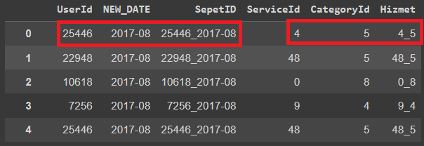

Hizmet ve SepetID

#### Birliktelik Kuralları Üretme

Birliktelik kuralları, müşterilerin birlikte aldığı hizmetler arasındaki ilişkileri belirlemek için kullanılmıştır. Bu süreçte aşağıdaki adımlar izlenmiştir

##### Sepet-Hizmet Pivot Tablosunun Oluşturulması

Müşterilerin aldıkları hizmetleri içeren bir sepet-hizmet pivot tablosu oluşturulmuştur. Bu tablo, her bir müşteri sepetinin hizmetlerle ilişkisini göstermektedir.

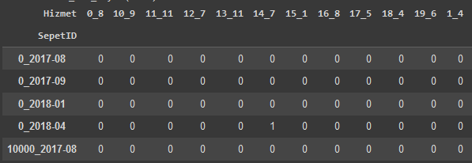

Sepet-Hizmet Pivot Tablosu

##### Apriori Algoritması Kullanarak Birliktelik Kurallarının Üretilmesi

Apriori algoritması, müşterilerin birlikte aldığı hizmetler arasındaki ilişkileri belirlemek için kullanılmıştır. Belirli bir destek değeri üzerinde olan sık görülen hizmet kombinasyonları tespit edilmiştir.

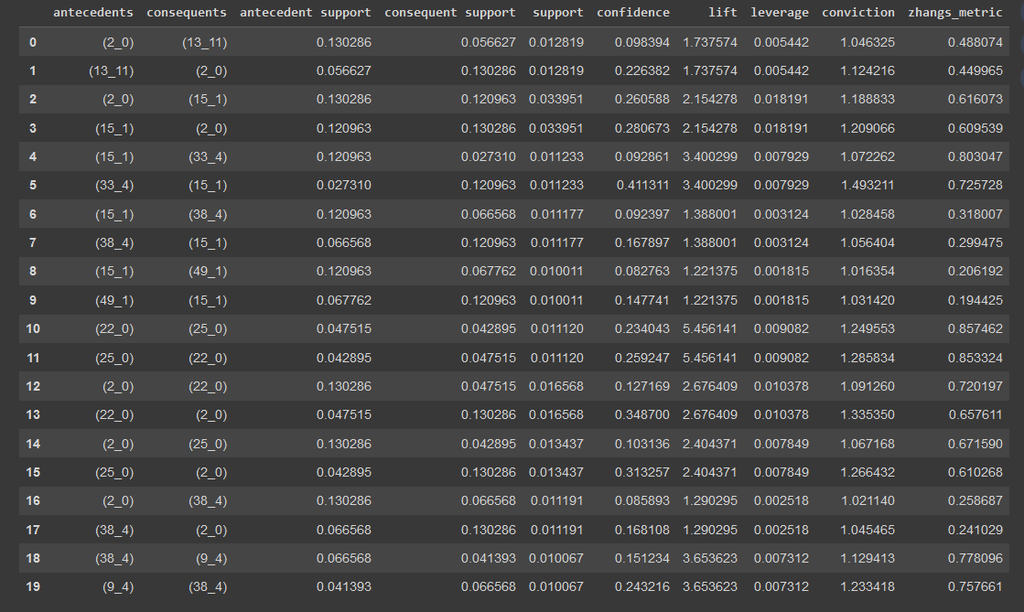

*Yukarıdaki tabloda birliktelik kuralları bulunmaktadır. Tavsiye algoritmasında confidence ve lift değerleri kullanılacaktır.*

### Zaman Serisi Analizi

Zaman serisi analizi, hizmetlerin zaman içindeki değişimlerini incelemek için yapılmıştır. Zaman serisi analizinin amacı, hizmet taleplerindeki trend bazlı değişiklikleri tespit etmektir.

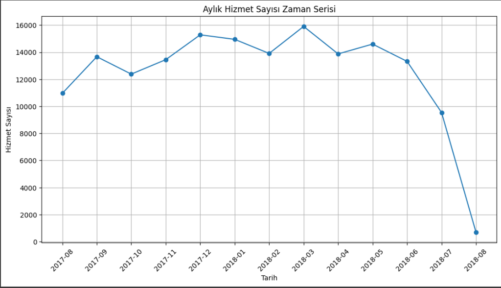

Hizmet Zaman Serisi Analizi

*Son aylarda bir düşüş olduğu görülmektedir. Bundan yola çıkarak komisyonlarda indirime gidilebilir. İleriki aylarda kampanyalar düzenlenebilir.*

## Sonuç

Bu analiz sonucunda, hizmetler arasındaki ilişkileri ve müşterilerin hizmet alım davranışlarını daha iyi anlamak için birliktelik kuralları kullanılarak hizmet önerileri oluşturulmuştur. Bu sistem, müşterilerin ilgilerine göre hizmet önerileri sunarak müşteri memnuniyetini ve hizmet kalitesini artırmayı hedeflemektedir.

Öneri sisteminin performansını artırmak ve daha kapsamlı analizler yapmak için veri setinin genişletilmesi ve farklı algoritmaların kullanılması mümkündür. Ayrıca, zaman serisi analizi ile elde edilen sonuçlar doğrultusunda mevsimsel kampanyalar ve müşteri sadakat programları oluşturulabilecektir.